# Relatedness Within and Between Years

Alan Couch

Tue Jun 21 12:08:51 PM 2016

```
## Loading project configuration
```

```
## Autoloading helper functions
```

```
##  Running helper script: funRel.R
```

```
## Autoloading cache
```

```
## Autoloading data
```

```
##  Loading data set: DARTallIdentifiers
```

```
##  Loading data set: qslAllLarvaInfo
```

```
##  Loading data set: qslAllLarvaInfo2015
```

```
##  Loading data set: qslAllLarvaInfoApr2016
```

```
##  Loading data set: qslMPeeliiForRelated
```

```
##  Loading data set: Report.DMac15.1861
```

```
## Munging data
```

```
##  Running preprocessing script: 01MungeGeneticsDatacontaminationfix.R
```

```
##  Running preprocessing script: 02MungeLarvaSnpsByYears.R
```

```
##  Running preprocessing script: 03MungeLarvaSnpsByYearCombos.R
```

Because the genetic diversity is low, and there is likely inbreeding among the extant population, the inbreeding mode for ‘related’ is set to on. This in turn means the maximum likliehood estimators must be used. This makes calculations much slower, so estimators are not compared for combinations of larvae/adults or years.

# Two of Each of the Three Years

# 2011 and 2012 Larval Relatedness

```r
#read file in
df<-eltwlarvalPeeliSnps; main<-"2011 and 2012 Larval snps"
df<-df[-c(1:4),]
```

```r
require(digest)
for (i in 1:length(df$X..2)) {
    df$unique[i] <- digest(df$X..2[i], algo = "xxhash32", seed = 1)
}
df <- cbind(df$unique, df)
names(df)[names(df) == "df$unique"] <- "allele"
df$unique <- NULL
df[1:10, c(1, 4)]
```

```
##       allele                                                                  X..2
## X5  a43f66cc                                                        AlleleSequence
## X6  127f06ec TGCAGGAGTCACGTTTCTCTCCCAAAACTCCCCTTAAGCTAAAAAACGTATAAATGAGAGCGTCAGCTA
## X7  756ac72f TGCAGGAGTCACGTTTCTCTCCCAAAACTCCCCTTAAGCTAAAAAACGTATAAATGAGAGTGTCAGCTA
## X8  648bd84a TGCAGAAATAAAGAACTTATTTTCAACCAACATGTCTTGTGATACCAAAGTTCTTTGGCCGCTATGTGC
## X9  9e1e8afc TGCAGAAATAAAGAATTTATTTTCAACCAACATGTCTTGTGATACCAAAGTTCTTTGGCCGCTATGTGC
## X10 d1899d1e TGCAGTGCTAATGCAGTTCGGAGGGCTTCTGCAATGCCTGTAAATGTGTACATGAGTATGTTTGTACAC
## X11 1beb420d TGCAGTGCTAATGCAGTTCGGGGGGCTTCTGCAATGCCTGTAAATGTGTACATGAGTATGTTTGTACAC
## X12 6a38a8f3 TGCAGTTGGACCCTTTGGTTGCCATTAGCCACGCTATCGTTTACTCCAGCTTTCCAAAACTGGGAAAGC
## X13 2630df0b TGCAGTTGGACCCTTTGGTTGCCATTAGCCACGCTATCGTTTACTCCAGCTTTCCAAAACTGGAAAAGC
## X14 c58a8999 TGCAGTTAACTCACCAAACTTTACTTTCCCACATTCCTAAAACCCCAGGCATTTGCATTATTTGAACCC
```

```r
df2 <- df
df2[2:18] <- list(NULL)
df2 <- setNames(data.frame(t(df2[, -1])), df2[, 1])
rownames(df2) <- df2[, 1]
fishID <- df2[, 1]
df2[, 1] <- NULL
colnames(df2) <- paste("X", colnames(df2), sep = "")
df2 <- as.data.frame(apply(df2, 2, function(x) gsub("\\s+", "", x)))
indx <- sapply(df2, is.factor)
df2[indx] <- lapply(df2[indx], function(x) as.numeric(as.character(x)))
rm(indx)
x <- df2
library(data.table)
setDT(x)
for (j in seq_along(x)) {
    set(x, i = which(x[[j]] == 1 & !is.na(x[[j]])), j = j, value = j)
}
d1 <- data.frame(x)
rm(x)
rm(i)
rm(j)
d1.lst <- lapply(seq(1, ncol(d1), by = 2), function(x) {
    return(d1[, x:(x + 1)])
})
d1.lst.fil <- lapply(d1.lst, function(x) {
    x[, 1][!is.na(x[, 1]) & x[, 1] == "0"] <- x[, 2][!is.na(x[, 1]) & x[, 1] == "0"]
    x[, 2][!is.na(x[, 2]) & x[, 2] == "0"] <- x[, 1][!is.na(x[, 2]) & x[, 2] == "0"]
    return(x)
})
df2 <- do.call(cbind, d1.lst.fil)
rm(d1)
rm(d1.lst)
rm(d1.lst.fil)
df2 <- cbind(fishID, df2)
rownames(df2) <- df2[, 1]
df2[, 1] <- NULL
write.table(df2[, 1:800], "outRelated.txt", sep = " ", col.names = FALSE, row.names = TRUE, quote = FALSE)
require(related)
input <- readgenotypedata("outRelated.txt")
output <- coancestry(input$gdata, allow.inbreeding = TRUE, trioml = 1, wang = 1, lynchli = 1, lynchrd = 1, ritland = 1, quellergt = 1, dyadml = 1)
```

```
##    user  system elapsed
##  572.01    0.34  576.48
##
## Reading output files into data.frames... Done!
```

```r
save(output, file = paste(c("output", main), collapse = " "))
write.table(output$relatedness, main, sep = ",", col.names = TRUE, row.names = TRUE)
head(output$relatedness)
```

```
##   pair.no ind1.id ind2.id group trioml   wang lynchli lynchrd ritland quellergt dyadml
## 1       1      70      71  7071 0.0659 0.1202  0.1254  0.0594  0.0537    0.1229 0.0659
## 2       2      70      72  7072 0.2879 0.3044  0.3083  0.2861  0.2677    0.3376 0.2879
## 3       3      70      73  7073 0.3620 0.4368  0.4371  0.3036  0.2433    0.3583 0.3671
## 4       4      70      76  7076 0.0000 0.2924  0.2858 -0.1305 -0.0793   -0.3532 0.0000
## 5       5      70      75  7075 0.2869 0.3966  0.3978  0.1845  0.1295    0.2273 0.2869
## 6       6      70      74  7074 0.1160 0.3541  0.3554  0.0977  0.0653    0.0589 0.1222
```

```r
head(output$inbreeding)
```

```
##   ind.id      LH      LR
## 1     70 -0.0304 -0.0342
## 2     71  0.0004  0.0004
## 3     72  0.0956  0.1022
## 4     73 -0.2152 -0.2227
## 5     76 -0.9091 -0.6602
## 6     75 -0.3989 -0.4033
```

So there are 400 loci being analysed. These are the first loci in the file ATM.

There are 2 alleles for each of these loci.

There are 107 individual fish in this set. From the simulations of ‘known’ relationships we can choose cut off values for identifying relationships and colouring them in the plots. In this case FS or PO above 0.4; HS 0.1-0.4; unrelated fish have a relatedness value below 0.15.

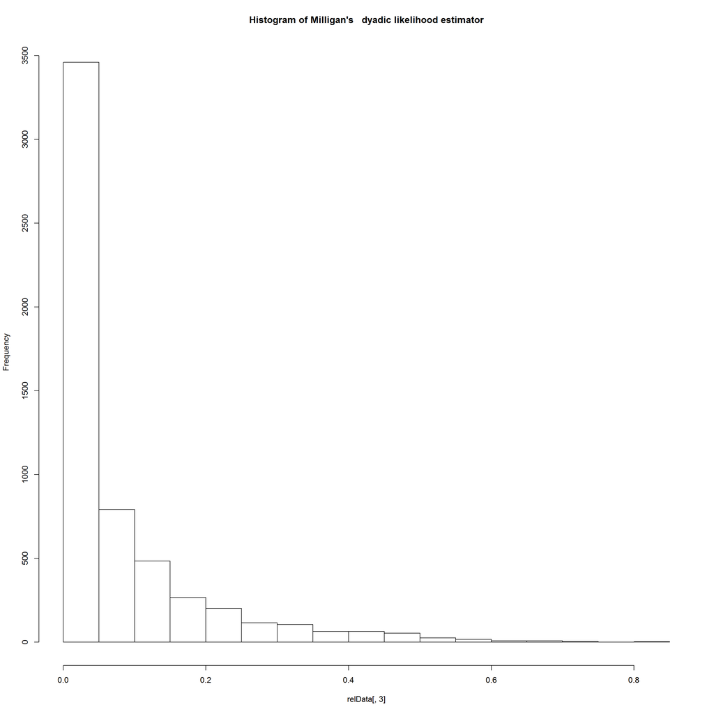

```r
require(igraph)
relData <- output$relatedness[, c(2, 3, 11)]
hist(relData[, 3], main = "Histogram of Milligan's   dyadic likelihood estimator")
```

```r
lrelData <- relData
colnames(lrelData)[1] <- "from"
colnames(lrelData)[2] <- "to"
colnames(lrelData)[3] <- "weight"
lrelData$type <- "probRel"
relDataNoRows <- nrow(relData)
nrelData <- data.frame(matrix(ncol = 4, nrow = relDataNoRows))
colnames(nrelData) <- c("id", "name", "type", "label")
nrelData[, 1] <- relData[, 2]
nrelData[, 2] <- relData[, 2]
newrow = c(relData[1, 1], relData[1, 1], NA, NA)
nrelData = rbind(nrelData, newrow)
nrow(nrelData)
```

```
## [1] 5672
```

```r
length(unique(nrelData$id))
```

```
## [1] 107
```

```r
nrow(lrelData)
```

```
## [1] 5671
```

```r
nrow(unique(lrelData[, c("from", "to")]))
```

```
## [1] 5671
```

```r
nrelData <- data.frame(unique(nrelData[, 1:4]))
tst <- ifelse(grepl("^A", nrelData$id), nrelData$type <- "adult", nrelData$type <- "larvae")
nrelData$type <- tst
rm(tst)
larvNrel <- merge(nrelData, larv, by.x = "id", by.y = "LarvalRecords_LarvaID")
larvNrel <- larvNrel[, c(1:4, 66)]
head(nrelData)
```

```
##   id name   type label
## 1 71   71 larvae  <NA>
## 2 72   72 larvae  <NA>
## 3 73   73 larvae  <NA>
## 4 76   76 larvae  <NA>
## 5 75   75 larvae  <NA>
## 6 74   74 larvae  <NA>
```

```r
head(larvNrel)
```

```
##    id name   type label YearOnly
## 1 100  100 larvae  <NA>     2011
## 2 101  101 larvae  <NA>     2011
## 3 103  103 larvae  <NA>     2011
## 4 104  104 larvae  <NA>     2011
## 5 105  105 larvae  <NA>     2011
## 6 107  107 larvae  <NA>     2011
```

```r
net <- graph_from_data_frame(d = lrelData, vertices = larvNrel, directed = FALSE)
```

## Refine set and Plot relationships

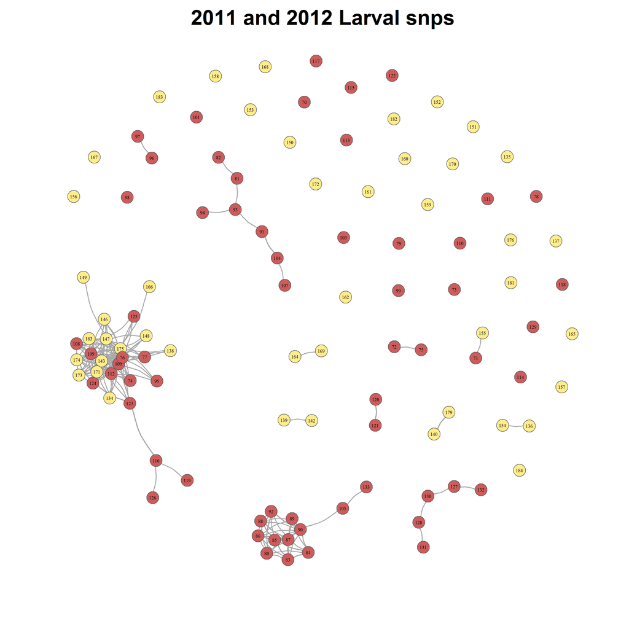

```r
#Limit to full siblings - this also makes it more sparse.
net.FS <- delete_edges(net, E(net)[weight<0.4])
l <- layout_with_fr(net.FS)

V(net.FS)$color=V(net.FS)$YearOnly #assign the "YearOnly" attribute as the vertex color
V(net.FS)$color=gsub("2011","indianred",V(net.FS)$color) #2011 will be red
V(net.FS)$color=gsub("2012","lightgoldenrod1",V(net.FS)$color) #2012 will be blue
V(net.FS)$color=gsub("2013","lightgreen",V(net.FS)$color) #2013 will be blue

E(net.FS)$weight<-E(net.FS)$weight*5

plot(net.FS, edge.arrow.size=0, edge.curved=0.2, vertex.size=5, vertex.color=V(net.FS)$color,vertex.frame.color="#555555",vertex.label=V(net)$name, vertex.label.color="black",vertex.label.cex=.7,edge.width=E(net.FS)$weight,layout=l)
#removed main=main;added edge.width=E(net.FS)$weight
title(main,cex.main=3)
legend(x=-1.5, y=-1.1, c("2011","2012", "2013"), pch=21,col="#777777", cex=.8, bty="n", ncol=1)
```

# 2011 and 2013 Larval Relatedness

```r
#read file in
df<-elthlarvalPeeliSnps; main<-"2011 and 2013 Larval snps"
df<-df[-c(1:4),]
```

```r
require(digest)
for (i in 1:length(df$X..2)) {
    df$unique[i] <- digest(df$X..2[i], algo = "xxhash32", seed = 1)
}
df <- cbind(df$unique, df)
names(df)[names(df) == "df$unique"] <- "allele"
df$unique <- NULL
df[1:10, c(1, 4)]
```

```
##       allele                                                                  X..2
## X5  a43f66cc                                                        AlleleSequence
## X6  127f06ec TGCAGGAGTCACGTTTCTCTCCCAAAACTCCCCTTAAGCTAAAAAACGTATAAATGAGAGCGTCAGCTA
## X7  756ac72f TGCAGGAGTCACGTTTCTCTCCCAAAACTCCCCTTAAGCTAAAAAACGTATAAATGAGAGTGTCAGCTA
## X8  648bd84a TGCAGAAATAAAGAACTTATTTTCAACCAACATGTCTTGTGATACCAAAGTTCTTTGGCCGCTATGTGC
## X9  9e1e8afc TGCAGAAATAAAGAATTTATTTTCAACCAACATGTCTTGTGATACCAAAGTTCTTTGGCCGCTATGTGC
## X10 d1899d1e TGCAGTGCTAATGCAGTTCGGAGGGCTTCTGCAATGCCTGTAAATGTGTACATGAGTATGTTTGTACAC
## X11 1beb420d TGCAGTGCTAATGCAGTTCGGGGGGCTTCTGCAATGCCTGTAAATGTGTACATGAGTATGTTTGTACAC
## X12 6a38a8f3 TGCAGTTGGACCCTTTGGTTGCCATTAGCCACGCTATCGTTTACTCCAGCTTTCCAAAACTGGGAAAGC
## X13 2630df0b TGCAGTTGGACCCTTTGGTTGCCATTAGCCACGCTATCGTTTACTCCAGCTTTCCAAAACTGGAAAAGC
## X14 c58a8999 TGCAGTTAACTCACCAAACTTTACTTTCCCACATTCCTAAAACCCCAGGCATTTGCATTATTTGAACCC
```

```r
df2 <- df
df2[2:18] <- list(NULL)
df2 <- setNames(data.frame(t(df2[, -1])), df2[, 1])
rownames(df2) <- df2[, 1]
fishID <- df2[, 1]
df2[, 1] <- NULL
colnames(df2) <- paste("X", colnames(df2), sep = "")
df2 <- as.data.frame(apply(df2, 2, function(x) gsub("\\s+", "", x)))
indx <- sapply(df2, is.factor)
df2[indx] <- lapply(df2[indx], function(x) as.numeric(as.character(x)))
rm(indx)
x <- df2
library(data.table)
setDT(x)
for (j in seq_along(x)) {
    set(x, i = which(x[[j]] == 1 & !is.na(x[[j]])), j = j, value = j)
}
d1 <- data.frame(x)
rm(x)
rm(i)
rm(j)
d1.lst <- lapply(seq(1, ncol(d1), by = 2), function(x) {
    return(d1[, x:(x + 1)])
})
d1.lst.fil <- lapply(d1.lst, function(x) {
    x[, 1][!is.na(x[, 1]) & x[, 1] == "0"] <- x[, 2][!is.na(x[, 1]) & x[, 1] == "0"]
    x[, 2][!is.na(x[, 2]) & x[, 2] == "0"] <- x[, 1][!is.na(x[, 2]) & x[, 2] == "0"]
    return(x)
})
df2 <- do.call(cbind, d1.lst.fil)
rm(d1)
rm(d1.lst)
rm(d1.lst.fil)
df2 <- cbind(fishID, df2)
rownames(df2) <- df2[, 1]
df2[, 1] <- NULL
write.table(df2[, 1:800], "outRelated.txt", sep = " ", col.names = FALSE, row.names = TRUE, quote = FALSE)
require(related)
input <- readgenotypedata("outRelated.txt")
output <- coancestry(input$gdata, allow.inbreeding = TRUE, trioml = 1, wang = 1, lynchli = 1, lynchrd = 1, ritland = 1, quellergt = 1, dyadml = 1)
```

```
##    user  system elapsed
## 1345.58    0.95 1352.34
##
## Reading output files into data.frames... Done!
```

```r
save(output, file = paste(c("output", main), collapse = " "))
write.table(output$relatedness, main, sep = ",", col.names = TRUE, row.names = TRUE)
head(output$relatedness)
```

```
##   pair.no ind1.id ind2.id group trioml   wang lynchli lynchrd ritland quellergt dyadml
## 1       1     185     186  1818 0.4596 0.4851  0.4861  0.4531  0.4201    0.4976 0.4634
## 2       2     185     187  1818 0.4959 0.4786  0.4845  0.5001  0.4902    0.5188 0.4980
## 3       3     185     188  1818 0.3124 0.3207  0.3283  0.3218  0.3046    0.3536 0.3163
## 4       4     185     189  1818 0.4580 0.4613  0.4657  0.4891  0.4908    0.5008 0.4624
## 5       5     185     190  1819 0.4668 0.4768  0.4814  0.4589  0.4235    0.4935 0.4696
## 6       6     185     191  1819 0.0000 0.0195  0.0252 -0.0358 -0.0327    0.0235 0.0000
```

```r
head(output$inbreeding)
```

```
##   ind.id      LH      LR
## 1    185  0.0566  0.0632
## 2    186 -0.0230 -0.0248
## 3    187  0.0723  0.0770
## 4    188  0.0151  0.0162
## 5    189  0.0841  0.0859
## 6    190  0.0010  0.0011
```

So there are 400 loci being analysed. These are the first loci in the file ATM.

There are 2 alleles for each of these loci.

There are 193 individual fish in this set.

From the simulations of ‘known’ relationships we can choose cut off values for identifying relationships and colouring them in the plots. In this case FS or PO above 0.4; HS 0.1-0.4; unrelated fish have a relatedness value below 0.15.

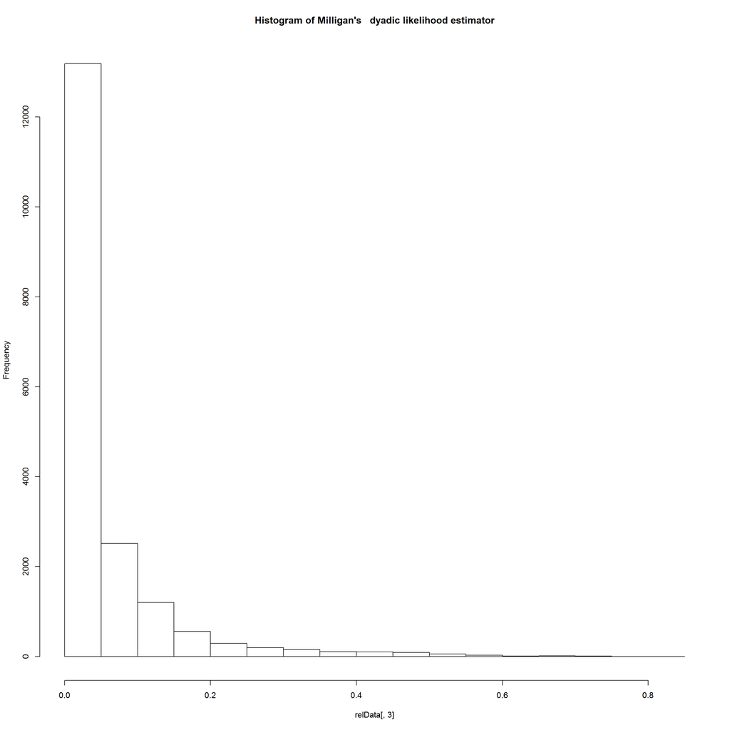

```r
require(igraph)
relData <- output$relatedness[, c(2, 3, 11)]
hist(relData[, 3], main = "Histogram of Milligan's   dyadic likelihood estimator")
```

```r
lrelData <- relData
colnames(lrelData)[1] <- "from"
colnames(lrelData)[2] <- "to"
colnames(lrelData)[3] <- "weight"
lrelData$type <- "probRel"
relDataNoRows <- nrow(relData)
nrelData <- data.frame(matrix(ncol = 4, nrow = relDataNoRows))
colnames(nrelData) <- c("id", "name", "type", "label")
nrelData[, 1] <- relData[, 2]
nrelData[, 2] <- relData[, 2]
newrow = c(relData[1, 1], relData[1, 1], NA, NA)
nrelData = rbind(nrelData, newrow)
nrow(nrelData)
```

```
## [1] 18529
```

```r
length(unique(nrelData$id))
```

```
## [1] 193
```

```r
nrow(lrelData)
```

```
## [1] 18528
```

```r
nrow(unique(lrelData[, c("from", "to")]))
```

```
## [1] 18528
```

```r
nrelData <- data.frame(unique(nrelData[, 1:4]))
tst <- ifelse(grepl("^A", nrelData$id), nrelData$type <- "adult", nrelData$type <- "larvae")
nrelData$type <- tst
rm(tst)
larvNrel <- merge(nrelData, larv, by.x = "id", by.y = "LarvalRecords_LarvaID")
larvNrel <- larvNrel[, c(1:4, 66)]
head(nrelData)
```

```
##    id name   type label
## 1 186  186 larvae  <NA>
## 2 187  187 larvae  <NA>
## 3 188  188 larvae  <NA>
## 4 189  189 larvae  <NA>
## 5 190  190 larvae  <NA>
## 6 191  191 larvae  <NA>
```

```r
head(larvNrel)
```

```
##    id name   type label YearOnly
## 1 100  100 larvae  <NA>     2011
## 2 101  101 larvae  <NA>     2011
## 3 103  103 larvae  <NA>     2011
## 4 104  104 larvae  <NA>     2011
## 5 105  105 larvae  <NA>     2011
## 6 107  107 larvae  <NA>     2011
```

```r
net <- graph_from_data_frame(d = lrelData, vertices = larvNrel, directed = FALSE)
```

## Refine Set and Plot relationships

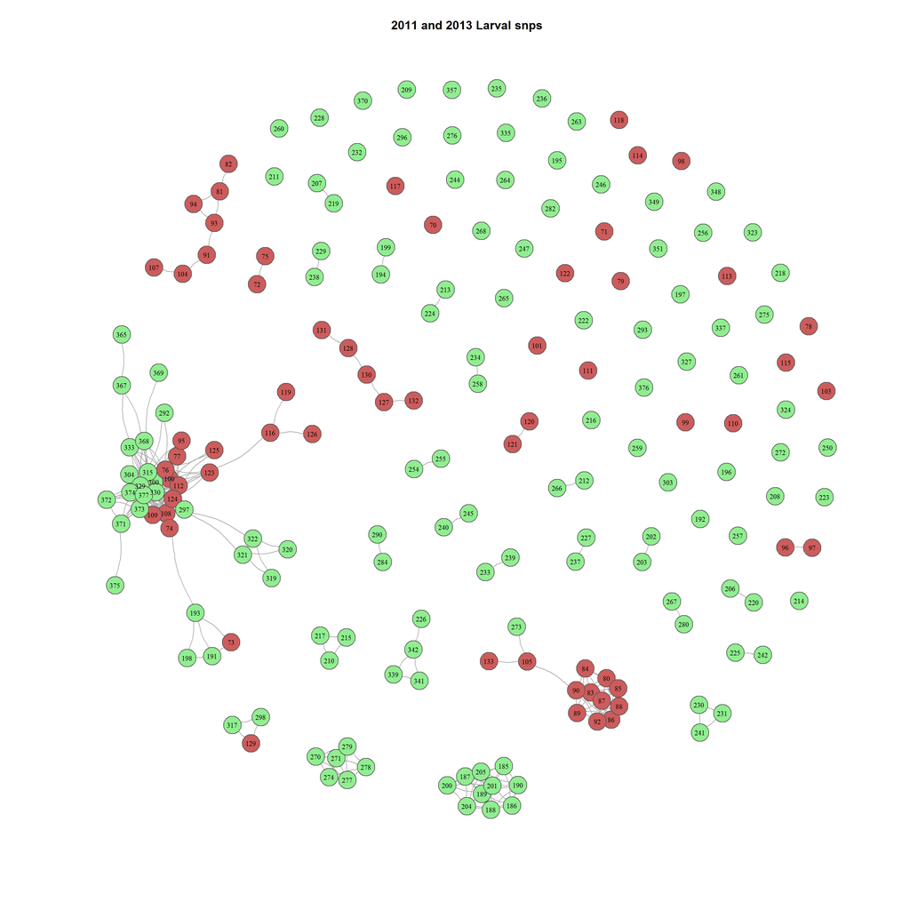

```r
#Limit to full siblings - this also makes it more sparse.
net.FS <- delete_edges(net, E(net)[weight<0.4])
l <- layout_with_fr(net.FS)

V(net.FS)$color=V(net.FS)$YearOnly #assign the "YearOnly" attribute as the vertex color
V(net.FS)$color=gsub("2011","indianred",V(net.FS)$color) #2011 will be red
V(net.FS)$color=gsub("2012","lightgoldenrod1",V(net.FS)$color) #2012 will be blue
V(net.FS)$color=gsub("2013","lightgreen",V(net.FS)$color) #2013 will be blue

plot(net.FS, edge.arrow.size=0, edge.curved=0.2, vertex.size=5, vertex.color=V(net.FS)$color,vertex.frame.color="#555555",vertex.label=V(net)$name, vertex.label.color="black",vertex.label.cex=.7,layout=l, main = main)
```

# 2012 and 2013 Larval Relatedness

```r
#read file in
df<-twthlarvalPeeliSnps; main<-"2012 and 2013 Larval snps"
df<-df[-c(1:4),]
```

```r
require(digest)
for (i in 1:length(df$X..2)) {
    df$unique[i] <- digest(df$X..2[i], algo = "xxhash32", seed = 1)
}
df <- cbind(df$unique, df)
names(df)[names(df) == "df$unique"] <- "allele"
df$unique <- NULL
df[1:10, c(1, 4)]
```

```
##       allele                                                                  X..2
## X5  a43f66cc                                                        AlleleSequence
## X6  127f06ec TGCAGGAGTCACGTTTCTCTCCCAAAACTCCCCTTAAGCTAAAAAACGTATAAATGAGAGCGTCAGCTA
## X7  756ac72f TGCAGGAGTCACGTTTCTCTCCCAAAACTCCCCTTAAGCTAAAAAACGTATAAATGAGAGTGTCAGCTA
## X8  648bd84a TGCAGAAATAAAGAACTTATTTTCAACCAACATGTCTTGTGATACCAAAGTTCTTTGGCCGCTATGTGC
## X9  9e1e8afc TGCAGAAATAAAGAATTTATTTTCAACCAACATGTCTTGTGATACCAAAGTTCTTTGGCCGCTATGTGC
## X10 d1899d1e TGCAGTGCTAATGCAGTTCGGAGGGCTTCTGCAATGCCTGTAAATGTGTACATGAGTATGTTTGTACAC
## X11 1beb420d TGCAGTGCTAATGCAGTTCGGGGGGCTTCTGCAATGCCTGTAAATGTGTACATGAGTATGTTTGTACAC
## X12 6a38a8f3 TGCAGTTGGACCCTTTGGTTGCCATTAGCCACGCTATCGTTTACTCCAGCTTTCCAAAACTGGGAAAGC
## X13 2630df0b TGCAGTTGGACCCTTTGGTTGCCATTAGCCACGCTATCGTTTACTCCAGCTTTCCAAAACTGGAAAAGC
## X14 c58a8999 TGCAGTTAACTCACCAAACTTTACTTTCCCACATTCCTAAAACCCCAGGCATTTGCATTATTTGAACCC
```

```r
df2 <- df
df2[2:18] <- list(NULL)
df2 <- setNames(data.frame(t(df2[, -1])), df2[, 1])
rownames(df2) <- df2[, 1]
fishID <- df2[, 1]
df2[, 1] <- NULL
colnames(df2) <- paste("X", colnames(df2), sep = "")
df2 <- as.data.frame(apply(df2, 2, function(x) gsub("\\s+", "", x)))
indx <- sapply(df2, is.factor)
df2[indx] <- lapply(df2[indx], function(x) as.numeric(as.character(x)))
rm(indx)
x <- df2
library(data.table)
setDT(x)
for (j in seq_along(x)) {
    set(x, i = which(x[[j]] == 1 & !is.na(x[[j]])), j = j, value = j)
}
d1 <- data.frame(x)
rm(x)
rm(i)
rm(j)
d1.lst <- lapply(seq(1, ncol(d1), by = 2), function(x) {
    return(d1[, x:(x + 1)])
})
d1.lst.fil <- lapply(d1.lst, function(x) {
    x[, 1][!is.na(x[, 1]) & x[, 1] == "0"] <- x[, 2][!is.na(x[, 1]) & x[, 1] == "0"]
    x[, 2][!is.na(x[, 2]) & x[, 2] == "0"] <- x[, 1][!is.na(x[, 2]) & x[, 2] == "0"]
    return(x)
})
df2 <- do.call(cbind, d1.lst.fil)
rm(d1)
rm(d1.lst)
rm(d1.lst.fil)
df2 <- cbind(fishID, df2)
rownames(df2) <- df2[, 1]
df2[, 1] <- NULL
write.table(df2[, 1:800], "outRelated.txt", sep = " ", col.names = FALSE, row.names = TRUE, quote = FALSE)
require(related)
input <- readgenotypedata("outRelated.txt")
output <- coancestry(input$gdata, allow.inbreeding = TRUE, trioml = 1, wang = 1, lynchli = 1, lynchrd = 1, ritland = 1, quellergt = 1, dyadml = 1)
```

```
##    user  system elapsed
## 1073.38    0.72 1080.78
##
## Reading output files into data.frames... Done!
```

```r
save(output, file = paste(c("output", main), collapse = " "))
write.table(output$relatedness, main, sep = ",", col.names = TRUE, row.names = TRUE)
head(output$relatedness)
```

```
##   pair.no ind1.id ind2.id group trioml   wang lynchli lynchrd ritland quellergt dyadml
## 1       1     185     186  1818 0.4488 0.4834  0.4848  0.4298  0.3821    0.4875 0.4512
## 2       2     185     187  1818 0.4773 0.4762  0.4833  0.4783  0.4449    0.5082 0.4838
## 3       3     185     188  1818 0.2918 0.3181  0.3267  0.2944  0.2660    0.3407 0.2950
## 4       4     185     189  1818 0.4471 0.4590  0.4645  0.4678  0.4488    0.4907 0.4510
## 5       5     185     190  1819 0.4549 0.4739  0.4801  0.4394  0.3859    0.4830 0.4578
## 6       6     185     191  1819 0.0000 0.0181  0.0229 -0.0610 -0.0549    0.0123 0.0000
```

```r
head(output$inbreeding)
```

```
##   ind.id      LH      LR
## 1    185  0.0400  0.0461
## 2    186 -0.0362 -0.0398
## 3    187  0.0486  0.0536
## 4    188 -0.0041 -0.0046
## 5    189  0.0637  0.0667
## 6    190 -0.0174 -0.0200
```

So there are 400 loci being analysed. These are the first loci in the file ATM.

There are 2 alleles for each of these loci.

There are 176 individual fish in this set. From the simulations of ‘known’ relationships we can choose cut off values for identifying relationships and colouring them in the plots. In this case FS or PO above 0.4; HS 0.1-0.4; unrelated fish have a relatedness value below 0.15.

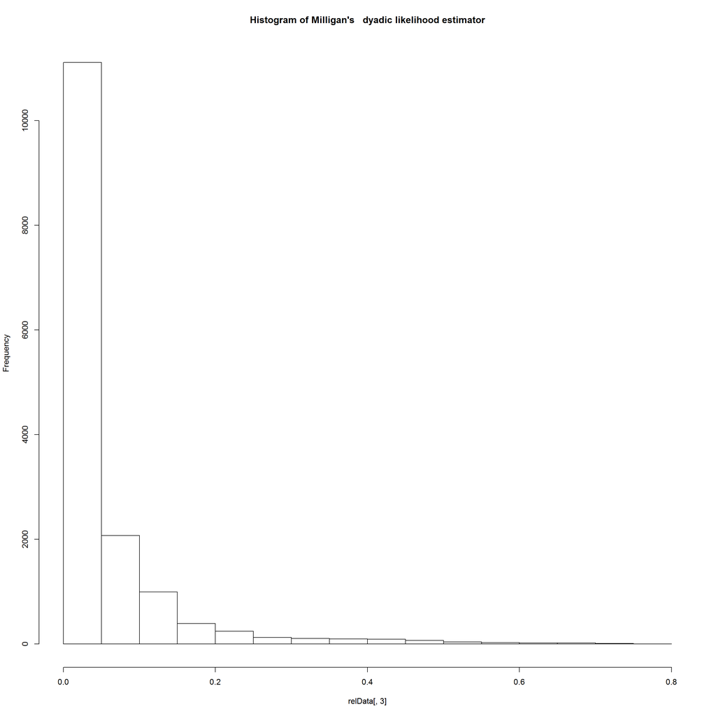

```r
require(igraph)
relData <- output$relatedness[, c(2, 3, 11)]
hist(relData[, 3], main = "Histogram of Milligan's   dyadic likelihood estimator")
```

```r
lrelData <- relData
colnames(lrelData)[1] <- "from"
colnames(lrelData)[2] <- "to"
colnames(lrelData)[3] <- "weight"
lrelData$type <- "probRel"
relDataNoRows <- nrow(relData)
nrelData <- data.frame(matrix(ncol = 4, nrow = relDataNoRows))
colnames(nrelData) <- c("id", "name", "type", "label")
nrelData[, 1] <- relData[, 2]
nrelData[, 2] <- relData[, 2]
newrow = c(relData[1, 1], relData[1, 1], NA, NA)
nrelData = rbind(nrelData, newrow)
nrow(nrelData)
```

```
## [1] 15401
```

```r
length(unique(nrelData$id))
```

```
## [1] 176
```

```r
nrow(lrelData)
```

```
## [1] 15400
```

```r
nrow(unique(lrelData[, c("from", "to")]))
```

```
## [1] 15400
```

```r
nrelData <- data.frame(unique(nrelData[, 1:4]))
tst <- ifelse(grepl("^A", nrelData$id), nrelData$type <- "adult", nrelData$type <- "larvae")
nrelData$type <- tst
rm(tst)
larvNrel <- merge(nrelData, larv, by.x = "id", by.y = "LarvalRecords_LarvaID")
larvNrel <- larvNrel[, c(1:4, 66)]
head(nrelData)
```

```
##    id name   type label
## 1 186  186 larvae  <NA>
## 2 187  187 larvae  <NA>
## 3 188  188 larvae  <NA>
## 4 189  189 larvae  <NA>
## 5 190  190 larvae  <NA>
## 6 191  191 larvae  <NA>
```

```r
head(larvNrel)
```

```
##    id name   type label YearOnly
## 1 134  134 larvae  <NA>     2012
## 2 135  135 larvae  <NA>     2012
## 3 136  136 larvae  <NA>     2012
## 4 137  137 larvae  <NA>     2012
## 5 138  138 larvae  <NA>     2012
## 6 139  139 larvae  <NA>     2012
```

```r
net <- graph_from_data_frame(d = lrelData, vertices = larvNrel, directed = FALSE)
```

## Refine Set and Plot relationships

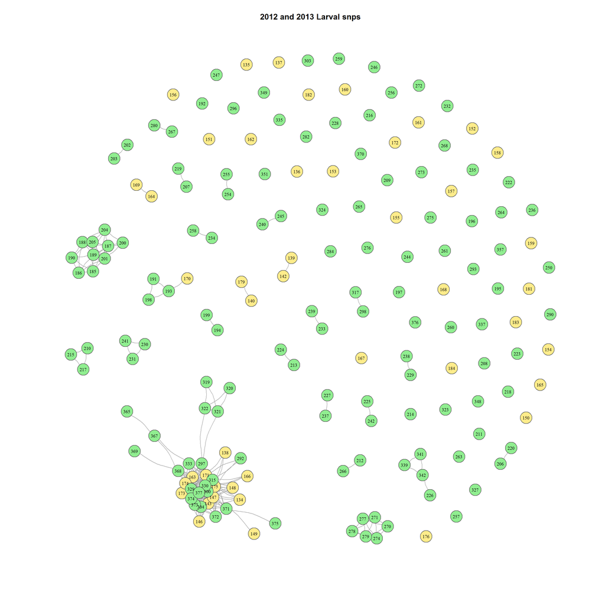

```r
#Limit to full siblings - this also makes it more sparse.
net.FS <- delete_edges(net, E(net)[weight<0.4])
l <- layout_with_fr(net.FS)

V(net.FS)$color=V(net.FS)$YearOnly #assign the "YearOnly" attribute as the vertex color
V(net.FS)$color=gsub("2011","indianred",V(net.FS)$color) #2011 will be red
V(net.FS)$color=gsub("2012","lightgoldenrod1",V(net.FS)$color) #2012 will be blue
V(net.FS)$color=gsub("2013","lightgreen",V(net.FS)$color) #2013 will be blue

plot(net.FS, edge.arrow.size=0, edge.curved=0.2, vertex.size=5, vertex.color=V(net.FS)$color,vertex.frame.color="#555555",vertex.label=V(net)$name, vertex.label.color="black",vertex.label.cex=.7,layout=l, main = main)
```

```r
all_labels()
```

```
##  [1] "Project_Template_and_Knitr"                    "Set_Global_Options"                            "unnamed-chunk-1"                               "unnamed-chunk-2"
##  [5] "Sibling Relationships in 2011 and 2012 Larvae" "Larvae2011and2012"                             "Larvae2011and2012Net"                          "unnamed-chunk-3"
##  [9] "Sibling Relationships in 2011 and 2013 Larvae" "Larvae2011and2013"                             "Larvae2011and2013Net"                          "unnamed-chunk-4"
## [13] "Sibling Relationships in 2012 and 2013 Larvae" "Larvae2012and2013"                             "Larvae2012and2013Net"                          "unnamed-chunk-5"
## [17] "Include_Chunk_Labels_and_Session Information"  "related"                                       "createNet"
```

```r
proc.time()-ptm
```

```
##    user  system elapsed
## 3148.21   22.17 3187.74
```